# Autoencoders for Anomaly Detection

Implement autoencoder and explore its application for a real-world problem related to anomaly detection. The final model achieves a test accuracy of greater than 80%.

**Datasets:** Numenta Anomaly Benchmark

## Step 1: Data preparation

1. Select and load one dataset from the list above.

```python
import pandas as pd

# Load the dataset
file_path = '/content/machine_temperature_system_failure.csv'
df = pd.read_csv(file_path, parse_dates=['timestamp'])

# Sort by time just in case
df.sort_values('timestamp', inplace=True)

# Basic inspection
print(df.head())
```

```
            timestamp      value
0 2013-12-02 21:15:00  73.967322
1 2013-12-02 21:20:00  74.935882
2 2013-12-02 21:25:00  76.124162
3 2013-12-02 21:30:00  78.140707
4 2013-12-02 21:35:00  79.329836
```

2. Analyze the dataset and provide the following statistics:
- Number of samples (time points)

```python
print("Number of Samples:", len(df))
```

```
Number of Samples: 22695
```

- Number of features

```python
num_features = df.drop(columns=['timestamp']).shape[1]
print("Number of Features:", num_features)
```

```
Number of Features: 1
```

- Mean, standard deviation, minimum, and maximum values for each feature (or relevant descriptive statistics depending on the data type)

```python
print(df['value'].describe())
```

```
count    22695.000000
mean        85.926498
std         13.746912
min          2.084721
25%         83.080078
50%         89.408246
75%         94.016252
max        108.510543
Name: value, dtype: float64
```

- Provide a brief description (2-3 sentences) of the dataset: What does it represent? Where does it come from (provide a link)? What are the key variables?

**Dataset Description:**

The `machine_temperature_system_failure.csv` dataset is part of the **Numenta Anomaly Benchmark** (NAB), designed for testing time-series anomaly detection models. It contains temperature readings from an industrial machine over time, with a recorded system failure event that presents as an anomaly in the data. The key variables include a timestamp and a single numeric feature value, which represents the machine’s temperature at each recorded time point.

**Source**: [NAB kaggle](https://www.kaggle.com/datasets/boltzmannbrain/nab)

3. Create at least three different visualizations to explore the dataset. Provide a short description explaining what each visualization shows.

Visualization and a short description # 1 : Temperature Over Time

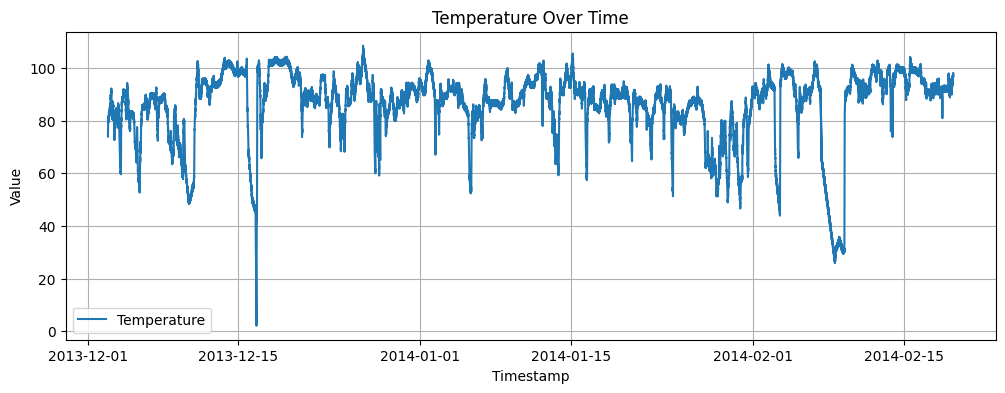

```python
import matplotlib.pyplot as plt

# Line plot
plt.figure(figsize=(12, 4))
plt.plot(df['timestamp'], df['value'], label='Temperature')
plt.title("Temperature Over Time")
plt.xlabel("Timestamp")
plt.ylabel("Value")
plt.legend()
plt.grid(True)
plt.show()
```

Visualization and a short description # 2 : Histogram of Temperature Values

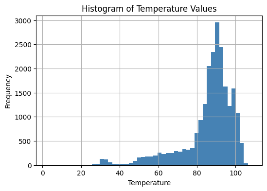

```python
import matplotlib.pyplot as plt

# Histogram
plt.figure(figsize=(6, 4))
plt.hist(df['value'], bins=50, color='steelblue')
plt.title("Histogram of Temperature Values")
plt.xlabel("Temperature")
plt.ylabel("Frequency")
plt.grid(True)
plt.show()
```

This histogram illustrates the distribution of temperature readings recorded by the machine. The majority of values are concentrated between 80°F and 100°F, indicating the typical operating range. A smaller number of lower temperature values, especially those below 60°F, appear less frequently and may correspond to anomalies or system failures. This plot helps highlight the skewness of the data and the presence of outliers on the lower end.

Visualization and a short description # 3 : Temperature with Rolling Mean

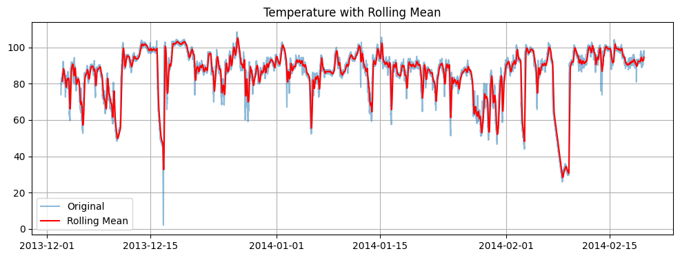

```python
import matplotlib.pyplot as plt

# Rolling Mean
df['rolling_mean'] = df['value'].rolling(window=50).mean()
plt.figure(figsize=(12, 4))
plt.plot(df['timestamp'], df['value'], alpha=0.5, label='Original')
plt.plot(df['timestamp'], df['rolling_mean'], color='red', label='Rolling Mean')
plt.title("Temperature with Rolling Mean")
plt.legend()
plt.grid(True)
plt.show()
```

This plot overlays a rolling (moving) mean of the temperature data (in red) on top of the original time series. The rolling mean smooths the short-term noise and reveals longer-term trends or shifts in the data. Large deviations between the original signal and the rolling mean can indicate potential anomalies. For example, abrupt drops that deviate significantly from the trend may correspond to system failure events.

4. Identify any missing values (e.g. using pandas.isnull().sum()). Handle any missing values (imputation or removal). Common imputation methods include: forward/backward fill, mean/median imputation, linear interpolation).

```python
# Check missing
print(df.isnull().sum())
```

```
timestamp        0
value            0
rolling_mean    49
dtype: int64
```

Checked for missing values and found no missing entries in the value column. Therefore, no imputation techniques were necessary for this dataset.

5. Preprocess the dataset.

a. Normalize the data.

```python
from sklearn.preprocessing import MinMaxScaler

scaler = MinMaxScaler()
df['value_scaled'] = scaler.fit_transform(df[['value']])
```

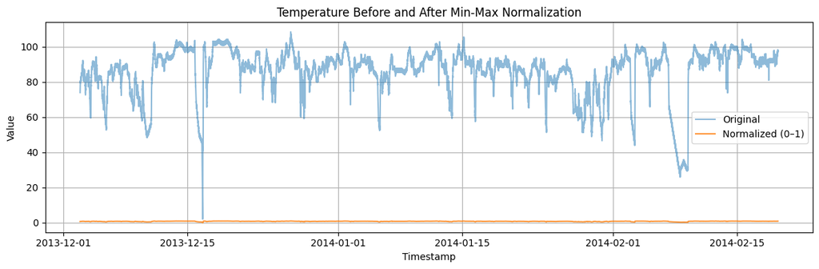

```python
import matplotlib.pyplot as plt

plt.figure(figsize=(12, 4))

# Original temperature values
plt.plot(df['timestamp'], df['value'], label='Original', alpha=0.5)

# Scaled values
plt.plot(df['timestamp'], df['value_scaled'], label='Normalized (0–1)', alpha=0.8)

plt.title("Temperature Before and After Min-Max Normalization")
plt.xlabel("Timestamp")
plt.ylabel("Value")
plt.legend()
plt.grid(True)
plt.tight_layout()
plt.show()
```

This plot compares the original and normalized temperature values over time. The original values span a wide range, while the normalized values are scaled to lie between 0 and 1 using Min-Max normalization. Although the normalized signal appears compressed near the x-axis due to the original scale, it still preserves the temporal structure and fluctuations of the raw data. This normalization ensures that all input values contribute equally during model training.

b. [If needed] Address class imbalance in the target column. Possible solutions: oversampling; undersampling; data augmentation techniques for the minority class; assign higher weights to the minority class and lower weights to the majority class, etc.

# **Not Applicable**

There is no explicit class label in this dataset. The autoencoder model will learn to reconstruct normal behavior, and anomalies will be inferred based on reconstruction error. Therefore, addressing class imbalance is not applicable at this preprocessing stage.

c. [If needed] Convert target variable needs to numerical format. You can use one-hot encoding. However, if you use torch.nn.CrossEntropyLoss for your network, it expects class indices (0, 1, 2) directly, not one-hot encoded vectors. Therefore, ensure your labels are integer tensors (e.g., torch.LongTensor).

# **Not Applicable**

This is an unsupervised setting with no predefined target labels. Thus, there is no need to convert target variables to numerical format at this stage.

6. Split the dataset into training, testing and validation sets. You can use train_test_split from scikit-learn.

```python
import numpy as np
from sklearn.model_selection import train_test_split

# Set window size
window_size = 50

# Create sliding windows
X = []
for i in range(len(df) - window_size):
    X.append(df['value_scaled'].iloc[i:i+window_size].values)

X = np.array(X)
print("Input shape:", X.shape)  # (samples, window_size)

# Train / validation / test split (no shuffle for time series!)
X_train, X_temp = train_test_split(X, test_size=0.3, shuffle=False)
X_val, X_test = train_test_split(X_temp, test_size=0.5, shuffle=False)

print(f"Train: {X_train.shape} | Val: {X_val.shape} | Test: {X_test.shape}")
```

```
Input shape: (22645, 50)
Train: (15851, 50) | Val: (3397, 50) | Test: (3397, 50)
```

## Step 2: Autoencoder model building

1. Choose and implement one of the following: Autoencoder,Variational Autoencoder (VAE) or other version of Autoencoder for anomaly detection.
2. Experiment with different architectures. Build and train 3 different autoencoder architectures for anomaly detection. Consider experimenting with:
   - Different layer types (Dense, LSTM for time series, Conv1D for sequential data)
   - Number of hidden layers and units
   - Activation functions (ReLU, sigmoid)
   - Print model summary using torchinfo.summary

### Model 1 Architecture

```python
import torch.nn as nn

class DenseAutoencoder(nn.Module):
    def __init__(self, input_dim=50, hidden_dims=[32, 16], bottleneck_dim=8, dropout=0.0):
        super(DenseAutoencoder, self).__init__()

        # Encoder
        self.encoder = nn.Sequential(
            nn.Linear(input_dim, hidden_dims[0]),
            nn.ReLU(),
            nn.Dropout(dropout),
            nn.Linear(hidden_dims[0], hidden_dims[1]),
            nn.ReLU(),
            nn.Dropout(dropout),
            nn.Linear(hidden_dims[1], bottleneck_dim)
        )

        # Decoder
        self.decoder = nn.Sequential(
            nn.Linear(bottleneck_dim, hidden_dims[1]),
            nn.ReLU(),
            nn.Dropout(dropout),
            nn.Linear(hidden_dims[1], hidden_dims[0]),
            nn.ReLU(),
            nn.Dropout(dropout),
            nn.Linear(hidden_dims[0], input_dim),
            nn.Sigmoid()
        )

    def forward(self, x):
        encoded = self.encoder(x)
        decoded = self.decoder(encoded)
        return decoded
```

Model summary

```python
from torchinfo import summary

dense_model = DenseAutoencoder(input_dim=50).to(device)
summary(dense_model, input_size=(32, 50))  # (batch_size, input_dim)
```

```
==========================================================================================
Layer (type:depth-idx)                   Output Shape              Param #
==========================================================================================
DenseAutoencoder                         [32, 50]                  --
├─Sequential: 1-1                        [32, 8]                   --
│    └─Linear: 2-1                       [32, 32]                  1,632
│    └─ReLU: 2-2                         [32, 32]                  --
│    └─Dropout: 2-3                      [32, 32]                  --
│    └─Linear: 2-4                       [32, 16]                  528
│    └─ReLU: 2-5                         [32, 16]                  --
│    └─Dropout: 2-6                      [32, 16]                  --
│    └─Linear: 2-7                       [32, 8]                   136
├─Sequential: 1-2                        [32, 50]                  --
│    └─Linear: 2-8                       [32, 16]                  144
│    └─ReLU: 2-9                         [32, 16]                  --
│    └─Dropout: 2-10                     [32, 16]                  --
│    └─Linear: 2-11                      [32, 32]                  544
│    └─ReLU: 2-12                        [32, 32]                  --
│    └─Dropout: 2-13                     [32, 32]                  --
│    └─Linear: 2-14                      [32, 50]                  1,650
│    └─Sigmoid: 2-15                     [32, 50]                  --
==========================================================================================
Total params: 4,634
Trainable params: 4,634
Non-trainable params: 0
Total mult-adds (Units.MEGABYTES): 0.15
==========================================================================================
Input size (MB): 0.01
Forward/backward pass size (MB): 0.04
Params size (MB): 0.02
Estimated Total Size (MB): 0.06
==========================================================================================
```

### Model 2 Architecture

```python
import torch.nn as nn

class LSTMAutoencoder(nn.Module):
    def __init__(self, input_dim=1, hidden_dim=32, bottleneck_dim=16, num_layers=1, seq_len=50, dropout=0.0):
        super(LSTMAutoencoder, self).__init__()
        self.seq_len = seq_len
        self.hidden_dim = hidden_dim

        # Encoder
        self.encoder_lstm = nn.LSTM(
            input_size=input_dim,
            hidden_size=hidden_dim,
            num_layers=num_layers,
            dropout=dropout if num_layers > 1 else 0.0,
            batch_first=True
        )

        self.bottleneck = nn.Linear(hidden_dim, bottleneck_dim)

        # Decoder
        self.decoder_lstm = nn.LSTM(
            input_size=bottleneck_dim,
            hidden_size=hidden_dim,
            num_layers=num_layers,
            dropout=dropout if num_layers > 1 else 0.0,
            batch_first=True
        )

        self.output_layer = nn.Linear(hidden_dim, input_dim)

    def forward(self, x):
        batch_size = x.size(0)

        # Encoder
        _, (h_n, _) = self.encoder_lstm(x)  # h_n: [num_layers, B, hidden_dim]
        h_last = h_n[-1]  # [B, hidden_dim]
        bottleneck_out = self.bottleneck(h_last)  # [B, bottleneck_dim]
        bottleneck_seq = bottleneck_out.unsqueeze(1).repeat(1, self.seq_len, 1)  # [B, seq_len, bottleneck_dim]

        # Decoder
        decoded, _ = self.decoder_lstm(bottleneck_seq)
        out = self.output_layer(decoded)
        return out
```

Model summary

```python
lstm_model = LSTMAutoencoder(input_dim=1, hidden_dim=32, seq_len=50).to(device)
summary(lstm_model, input_size=(32, 50, 1))  # (batch_size, seq_len, input_dim)
```

```
==========================================================================================
Layer (type:depth-idx)                   Output Shape              Param #
==========================================================================================
LSTMAutoencoder                          [32, 50, 1]               --
├─LSTM: 1-1                              [32, 50, 32]              4,480
├─Linear: 1-2                            [32, 16]                  528
├─LSTM: 1-3                              [32, 50, 32]              6,400
├─Linear: 1-4                            [32, 50, 1]               33
==========================================================================================
Total params: 11,441
Trainable params: 11,441
Non-trainable params: 0
Total mult-adds (Units.MEGABYTES): 17.43
==========================================================================================
Input size (MB): 0.01
Forward/backward pass size (MB): 0.84
Params size (MB): 0.05
Estimated Total Size (MB): 0.89
==========================================================================================
```

### Model 3 Architecture

```python
import torch.nn as nn

class Conv1DAutoencoder(nn.Module):
    def __init__(self, input_channels=1, conv_channels=[16, 8], seq_len=50, dropout=0.0):
        super(Conv1DAutoencoder, self).__init__()

        self.encoder = nn.Sequential(
            nn.Conv1d(input_channels, conv_channels[0], kernel_size=3, padding=1),
            nn.ReLU(),
            nn.Dropout(dropout),
            nn.Conv1d(conv_channels[0], conv_channels[1], kernel_size=3, padding=1),
            nn.ReLU(),
            nn.Dropout(dropout)
        )

        self.decoder = nn.Sequential(
            nn.ConvTranspose1d(conv_channels[1], conv_channels[0], kernel_size=3, padding=1),
            nn.ReLU(),
            nn.Dropout(dropout),
            nn.ConvTranspose1d(conv_channels[0], input_channels, kernel_size=3, padding=1),
            nn.Sigmoid()
        )

    def forward(self, x):
        encoded = self.encoder(x)
        decoded = self.decoder(encoded)
        return decoded
```

```python
conv_model = Conv1DAutoencoder(input_channels=1, seq_len=50).to(device)
summary(conv_model, input_size=(32, 1, 50))  # (batch_size, channels, seq_len)
```

```
==========================================================================================
Layer (type:depth-idx)                   Output Shape              Param #
==========================================================================================
Conv1DAutoencoder                        [32, 1, 50]               --
├─Sequential: 1-1                        [32, 8, 50]               --
│    └─Conv1d: 2-1                       [32, 16, 50]              64
│    └─ReLU: 2-2                         [32, 16, 50]              --
│    └─Dropout: 2-3                      [32, 16, 50]              --
│    └─Conv1d: 2-4                       [32, 8, 50]               392
│    └─ReLU: 2-5                         [32, 8, 50]               --
│    └─Dropout: 2-6                      [32, 8, 50]               --
├─Sequential: 1-2                        [32, 1, 50]               --
│    └─ConvTranspose1d: 2-7              [32, 16, 50]              400
│    └─ReLU: 2-8                         [32, 16, 50]              --
│    └─Dropout: 2-9                      [32, 16, 50]              --
│    └─ConvTranspose1d: 2-10             [32, 1, 50]               49
│    └─Sigmoid: 2-11                     [32, 1, 50]               --
==========================================================================================
Total params: 905
Trainable params: 905
Non-trainable params: 0
Total mult-adds (Units.MEGABYTES): 1.45
==========================================================================================
Input size (MB): 0.01
Forward/backward pass size (MB): 0.52
Params size (MB): 0.00
Estimated Total Size (MB): 0.53
==========================================================================================
```

Model summary

3. Model training and hyperparameter tuning:
   - Choose an appropriate loss function and optimizer (e.g., Adam).
   - Train your model and monitor its performance on the training and validation sets.
   - Tune hyperparameters (learning rate, batch size, number of epochs, hidden units, dropout rate) using the validation set.
   - Plot the training and validation loss and accuracy curves over epochs. Analyze the plots for signs of overfitting or underfitting. Adjust your model or hyperparameters if needed.

Training Loop

```python
import torch
import torch.nn as nn
from torch.utils.data import DataLoader, TensorDataset
import matplotlib.pyplot as plt
import pickle
# for reproducibility in DataLoader
g = torch.Generator()
g.manual_seed(SEED)


def train_model(model,
                train_data,
                val_data,
                loss_fn,
                optimizer,
                num_epochs=20,
                batch_size=32,
                device=device,
                save_path=None):

    model.to(device)

    # Prepare PyTorch DataLoaders for training and validation
    train_loader = DataLoader(TensorDataset(torch.tensor(train_data, dtype=torch.float32)),
                              batch_size=batch_size, shuffle=True, generator=g)
    val_loader = DataLoader(TensorDataset(torch.tensor(val_data, dtype=torch.float32)),
                            batch_size=batch_size, shuffle=False)

    train_losses = []
    val_losses = []

    best_val_loss = float('inf')
    best_model_state = None

    for epoch in range(num_epochs):
        model.train()
        running_train_loss = 0.0

        for batch in train_loader:
            inputs = batch[0].to(device)

            # Adjust input shape
            if isinstance(model, DenseAutoencoder):
                pass
            if isinstance(model, LSTMAutoencoder):
                inputs = inputs.unsqueeze(-1)
            elif isinstance(model, Conv1DAutoencoder):
                inputs = inputs.unsqueeze(1)

            outputs = model(inputs)
            loss = loss_fn(outputs, inputs)

            optimizer.zero_grad()
            loss.backward()
            optimizer.step()
            running_train_loss += loss.item()

        avg_train_loss = running_train_loss / len(train_loader)
        train_losses.append(avg_train_loss)

        # Evaluate on validation set
        model.eval()
        running_val_loss = 0.0
        with torch.no_grad():
            for batch in val_loader:
                inputs = batch[0].to(device)

                if isinstance(model, LSTMAutoencoder):
                    inputs = inputs.unsqueeze(-1)
                elif isinstance(model, Conv1DAutoencoder):
                    inputs = inputs.unsqueeze(1)

                outputs = model(inputs)
                loss = loss_fn(outputs, inputs)
                running_val_loss += loss.item()

        avg_val_loss = running_val_loss / len(val_loader)
        val_losses.append(avg_val_loss)

        # Checkpoint best model
        if avg_val_loss < best_val_loss:
            best_val_loss = avg_val_loss
            best_model_state = model.state_dict().copy()

        print(f"Epoch {epoch+1}/{num_epochs} | Train Loss: {avg_train_loss:.4f} | Val Loss: {avg_val_loss:.4f}")

    # Load best model weights
    model.load_state_dict(best_model_state)

    # Save model and metadata
    if save_path:
        # Save model weights (.pt)
        torch.save(model.state_dict(), save_path)
        print(f"Best model weights saved to: {save_path}")

        # Save training metadata (.pkl)
        metadata = {
            'train_losses': train_losses,
            'val_losses': val_losses,
            'best_val_loss': best_val_loss,
            'num_epochs': num_epochs,
            'batch_size': batch_size,
            'optimizer': optimizer.__class__.__name__,
            'loss_fn': loss_fn.__class__.__name__,
        }

        meta_path = save_path.replace('.pt', '.pkl')
        with open(meta_path, 'wb') as f:
            pickle.dump(metadata, f)
        print(f"Training metadata saved to: {meta_path}")

    # Plot training/validation loss curves
    plt.figure(figsize=(8, 4))
    plt.plot(train_losses, label='Train Loss')
    plt.plot(val_losses, label='Validation Loss')
    plt.title(f"Training vs. Validation Loss: {save_path}")
    plt.xlabel("Epoch")
    plt.ylabel("Loss")
    plt.legend()
    plt.grid(True)
    plt.tight_layout()
    plt.show()

    return model, train_losses, val_losses
```

# **Model training and hyperparameter tuning**

# **Dense**

Test Run

```
Best model weights saved to: best_dense_model.pt
Training metadata saved to: best_dense_model.pkl
```

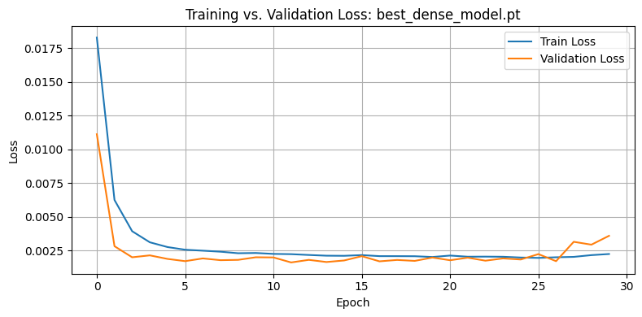

```python
model = DenseAutoencoder(
    input_dim=50,
    hidden_dims=[64, 32],
    bottleneck_dim=16,
    dropout=0.3
)

loss_fn = nn.MSELoss()
optimizer = torch.optim.Adam(model.parameters(), lr=0.001)

best_dense_model, train_loss_dense, val_loss_dense = train_model(
    model=model,
    train_data=X_train,
    val_data=X_val,
    loss_fn=loss_fn,
    optimizer=optimizer,
    num_epochs=30,
    batch_size=64,
    device=device,
    save_path='best_dense_model.pt'
)
```

Experiment 01 - Smaller Hidden Layers to reduce overfitting capacity

```
Best model weights saved to: best_dense_model_1.pt
Training metadata saved to: best_dense_model_1.pkl
```

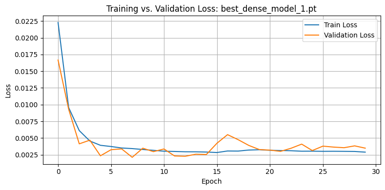

```python
model = DenseAutoencoder(
    input_dim=50,
    hidden_dims=[32, 16],       # reduced hidden layer size
    bottleneck_dim=8,           # smaller bottleneck
    dropout=0.3
)

loss_fn = nn.MSELoss()
optimizer = torch.optim.Adam(model.parameters(), lr=0.001)

best_dense_model_1, train_loss_1, val_loss_1 = train_model(
    model=model,
    train_data=X_train,
    val_data=X_val,
    loss_fn=loss_fn,
    optimizer=optimizer,
    num_epochs=30,
    batch_size=64,
    device=device,
    save_path='best_dense_model_1.pt'
)
```

Experiment 02 - Increased Dropout (stronger regularization)

```
Best model weights saved to: best_dense_model_2.pt
Training metadata saved to: best_dense_model_2.pkl
```

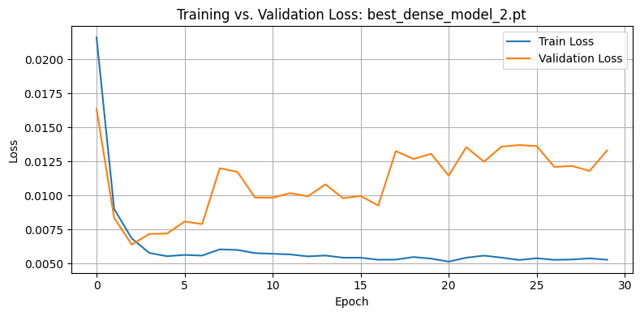

```python
model = DenseAutoencoder(
    input_dim=50,
    hidden_dims=[64, 32],
    bottleneck_dim=16,
    dropout=0.5                 # increased from 0.3 → 0.5
)
loss_fn = nn.MSELoss()
optimizer = torch.optim.Adam(model.parameters(), lr=0.001)

best_dense_model_1, train_loss_1, val_loss_1 = train_model(
    model=model,
    train_data=X_train,
    val_data=X_val,
    loss_fn=loss_fn,
    optimizer=optimizer,
    num_epochs=30,
    batch_size=64,
    device=device,
    save_path='best_dense_model_2.pt'
)
```

Experiment 03 - Lower Learning Rate (improve late-stage convergence)

```
Best model weights saved to: best_dense_model_3.pt
Training metadata saved to: best_dense_model_3.pkl
```

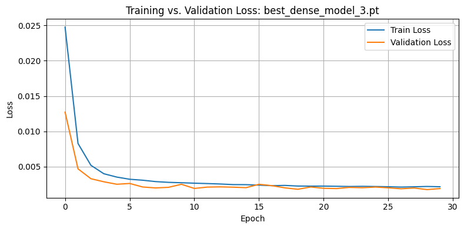

```python
model = DenseAutoencoder(
    input_dim=50,
    hidden_dims=[64, 32],
    bottleneck_dim=16,
    dropout=0.3
)
loss_fn = nn.MSELoss()
optimizer = torch.optim.Adam(model.parameters(), lr=0.0005)  # ↓ from 0.001

best_dense_model_1, train_loss_1, val_loss_1 = train_model(
    model=model,
    train_data=X_train,
    val_data=X_val,
    loss_fn=loss_fn,
    optimizer=optimizer,
    num_epochs=30,
    batch_size=64,
    device=device,
    save_path='best_dense_model_3.pt'
)
```

Experiment 04 - Wider Hidden Layers

```
Best model weights saved to: best_dense_model_4.pt
Training metadata saved to: best_dense_model_4.pkl
```

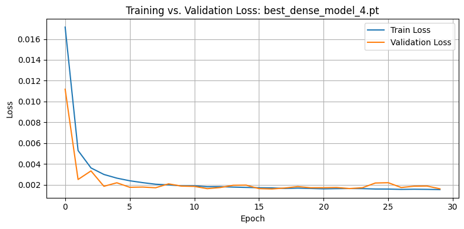

```python
model = DenseAutoencoder(
    input_dim=50,
    hidden_dims=[128, 64],     #Increased width
    bottleneck_dim=16,
    dropout=0.3
)
optimizer = torch.optim.Adam(model.parameters(), lr=0.0005)

best_dense_model_1, train_loss_1, val_loss_1 = train_model(
    model=model,
    train_data=X_train,
    val_data=X_val,
    loss_fn=loss_fn,
    optimizer=optimizer,
    num_epochs=30,
    batch_size=64,
    device=device,
    save_path='best_dense_model_4.pt'
)
```

```
Best model weights saved to: best_dense_model_5.pt
Training metadata saved to: best_dense_model_5.pkl
```

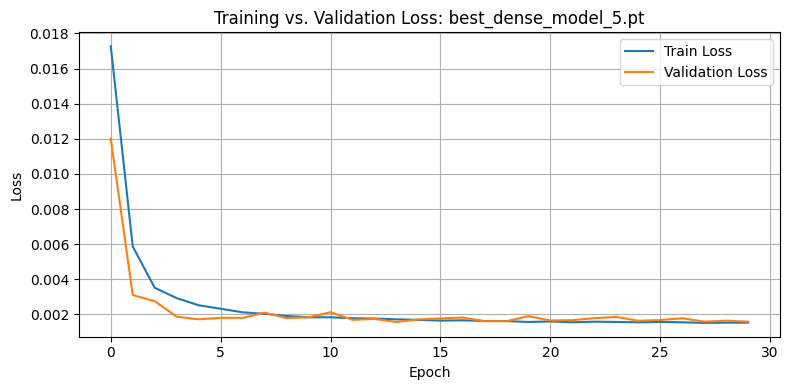

```python
model = DenseAutoencoder(
    input_dim=50,
    hidden_dims=[128, 64, 32],  #Deeper path to bottleneck
    bottleneck_dim=16,
    dropout=0.3
)
optimizer = torch.optim.Adam(model.parameters(), lr=0.0005)

best_dense_model_1, train_loss_1, val_loss_1 = train_model(
    model=model,
    train_data=X_train,
    val_data=X_val,
    loss_fn=loss_fn,
    optimizer=optimizer,
    num_epochs=30,
    batch_size=64,
    device=device,
    save_path='best_dense_model_5.pt'
)
```

By comparison:

# **LSTM**

Test Run

```
Best model weights saved to: best_lstm_model.pt
Training metadata saved to: best_lstm_model.pkl
```

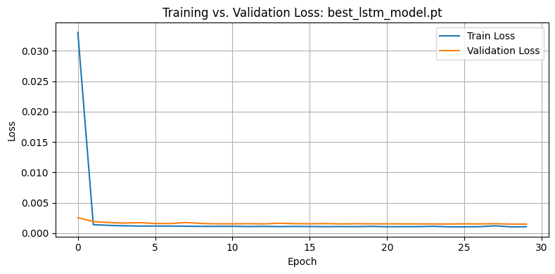

```python
model = LSTMAutoencoder(
    input_dim=1,
    hidden_dim=64,
    bottleneck_dim=32,
    seq_len=50,
    dropout=0.3
)

loss_fn = nn.MSELoss()
optimizer = torch.optim.Adam(model.parameters(), lr=0.001)

best_lstm_model, train_loss_lstm, val_loss_lstm = train_model(
    model=model,
    train_data=X_train,
    val_data=X_val,
    loss_fn=loss_fn,
    optimizer=optimizer,
    num_epochs=30,
    batch_size=64,
    device=device,
    save_path='best_lstm_model.pt'
)
```

Experiment 01 (LSTM) - Reduced Model Size

```
Best model weights saved to: best_lstm_model_1.pt
Training metadata saved to: best_lstm_model_1.pkl
```

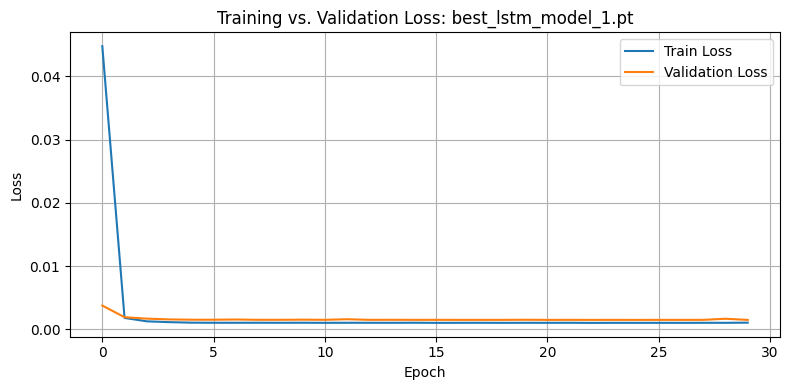

```python
model = LSTMAutoencoder(
    input_dim=1,
    hidden_dim=32,          # ↓ smaller LSTM hidden dim
    bottleneck_dim=16,      # ↓ smaller compressed representation
    seq_len=50,
    dropout=0.3             # unchanged for now
)

optimizer = torch.optim.Adam(model.parameters(), lr=0.001)

best_lstm_model, train_loss_lstm, val_loss_lstm = train_model(
    model=model,
    train_data=X_train,
    val_data=X_val,
    loss_fn=loss_fn,
    optimizer=optimizer,
    num_epochs=30,
    batch_size=64,
    device=device,
    save_path='best_lstm_model_1.pt'
)
```

Experiment 02 - Larger LSTM

```
Best model weights saved to: best_lstm_model_2.pt
Training metadata saved to: best_lstm_model_2.pkl
```

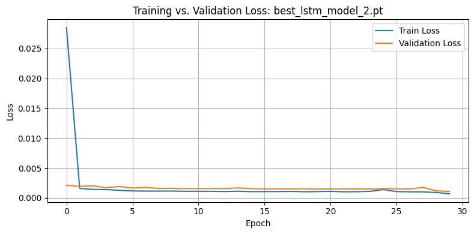

```python
model = LSTMAutoencoder(
    input_dim=1,
    hidden_dim=128,         # ↑ LSTM size
    bottleneck_dim=64,      # ↑ more space for encoded representation
    seq_len=50,
    dropout=0.3
)

optimizer = torch.optim.Adam(model.parameters(), lr=0.001)

best_lstm_model, train_loss_lstm, val_loss_lstm = train_model(
    model=model,
    train_data=X_train,
    val_data=X_val,
    loss_fn=loss_fn,
    optimizer=optimizer,
    num_epochs=30,
    batch_size=64,
    device=device,
    save_path='best_lstm_model_2.pt'
)
```

Experiment 03 - Smoother Learning Attempt

```
Best model weights saved to: best_lstm_model_3.pt
Training metadata saved to: best_lstm_model_3.pkl
```

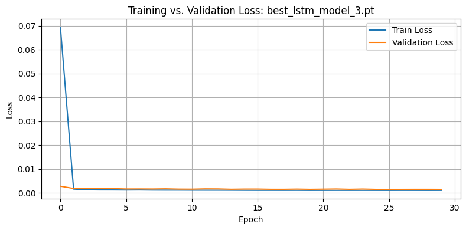

```python
model = LSTMAutoencoder(
    input_dim=1,
    hidden_dim=64,
    bottleneck_dim=32,
    seq_len=50,
    dropout=0.3
)

optimizer = torch.optim.Adam(model.parameters(), lr=0.0005)  # ↓ slower learning

best_lstm_model, train_loss_lstm, val_loss_lstm = train_model(
    model=model,
    train_data=X_train,
    val_data=X_val,
    loss_fn=loss_fn,
    optimizer=optimizer,
    num_epochs=30,
    batch_size=64,
    device=device,
    save_path='best_lstm_model_3.pt'
)
```

# **Conv1D**

Test Run

```
Best model weights saved to: best_conv_model.pt
Training metadata saved to: best_conv_model.pkl
```

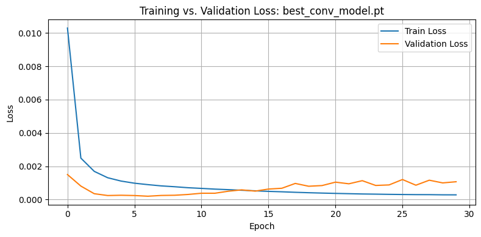

```python
model = Conv1DAutoencoder(
    input_channels=1,
    conv_channels=[32, 16],
    seq_len=50,
    dropout=0.3
)

loss_fn = nn.MSELoss()
optimizer = torch.optim.Adam(model.parameters(), lr=0.001)

best_conv_model, train_loss_conv, val_loss_conv = train_model(
    model=model,
    train_data=X_train,
    val_data=X_val,
    loss_fn=loss_fn,
    optimizer=optimizer,
    num_epochs=30,
    batch_size=64,
    device=device,
    save_path='best_conv_model.pt'
)
```

Experiment 01 - Conv1D

```
Best model weights saved to: best_conv_model_1.pt
Training metadata saved to: best_conv_model_1.pkl
```

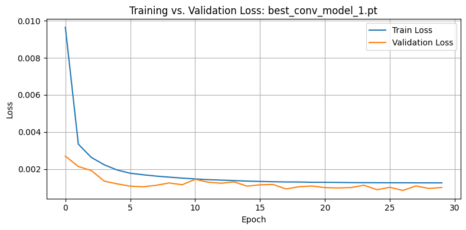

```python
model = Conv1DAutoencoder(
    input_channels=1,
    conv_channels=[16, 8],  # ↓ fewer channels
    seq_len=50,
    dropout=0.3
)

optimizer = torch.optim.Adam(model.parameters(), lr=0.001)

best_conv_model, train_loss_conv, val_loss_conv = train_model(
    model=model,
    train_data=X_train,
    val_data=X_val,
    loss_fn=loss_fn,
    optimizer=optimizer,
    num_epochs=30,
    batch_size=64,
    device=device,
    save_path='best_conv_model_1.pt'
)
```

Experiment 02

```
Best model weights saved to: best_conv_model_2.pt
Training metadata saved to: best_conv_model_2.pkl
```

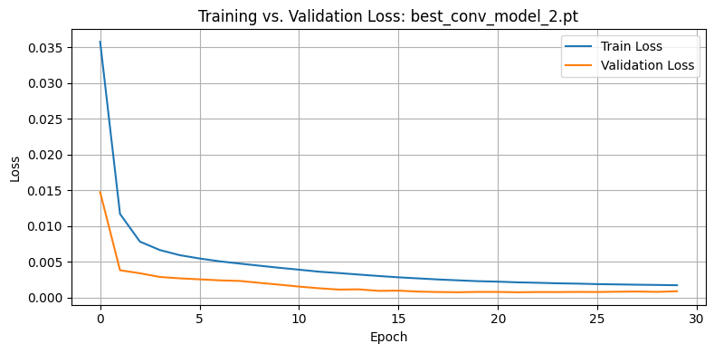

```python
model = Conv1DAutoencoder(
    input_channels=1,
    conv_channels=[8, 4],  # further reduced capacity
    seq_len=50,
    dropout=0.3
)

optimizer = torch.optim.Adam(model.parameters(), lr=0.001)
best_conv_model, train_loss_conv, val_loss_conv = train_model(
    model=model,
    train_data=X_train,
    val_data=X_val,
    loss_fn=loss_fn,
    optimizer=optimizer,
    num_epochs=30,
    batch_size=64,
    device=device,
    save_path='best_conv_model_2.pt'
)
```

Experiment 03 - Controlled Boost

```
Best model weights saved to: best_conv_model_3.pt
Training metadata saved to: best_conv_model_3.pkl
```

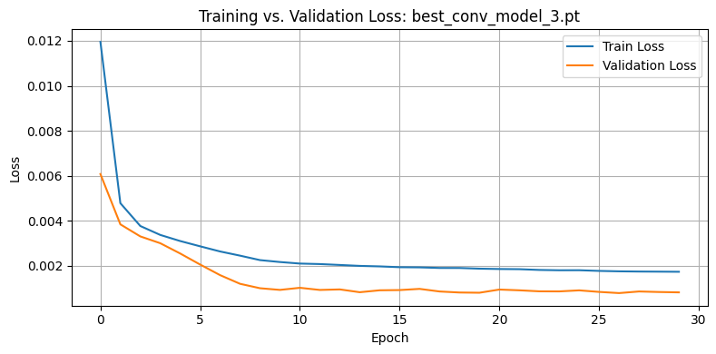

```python
model = Conv1DAutoencoder(
    input_channels=1,
    conv_channels=[16, 8],
    dropout=0.5
)

optimizer = torch.optim.Adam(model.parameters(), lr=0.001)

best_conv_model, train_loss_conv, val_loss_conv = train_model(
    model=model,
    train_data=X_train,
    val_data=X_val,
    loss_fn=loss_fn,
    optimizer=optimizer,
    num_epochs=30,
    batch_size=64,
    device=device,
    save_path='best_conv_model_3.pt'
)
```

Experiment 04

```
Best model weights saved to: best_conv_model_4.pt
Training metadata saved to: best_conv_model_4.pkl
```

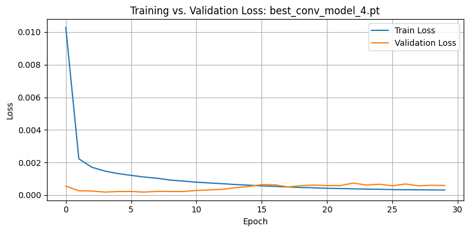

```python
model = Conv1DAutoencoder(
    input_channels=1,
    conv_channels=[32, 16],  # slightly higher than [8, 4]
    seq_len=50,
    dropout=0.3
)

optimizer = torch.optim.Adam(model.parameters(), lr=0.001)
best_conv_model_4, train_loss_4, val_loss_4 = train_model(
    model=model,
    train_data=X_train,
    val_data=X_val,
    loss_fn=loss_fn,
    optimizer=optimizer,
    num_epochs=30,
    batch_size=64,
    device=device,
    save_path='best_conv_model_4.pt'
)
```

# **Overall Best Model**

4. Save the weights of the trained neural network that provides the best results. Check saving and loading models (PyTorch)

```python
import torch

# Re-create the exact architecture used for best_dense_model_5.pt
best_model = DenseAutoencoder(
    input_dim=50,
    hidden_dims=[128, 64, 32],
    bottleneck_dim=16,
    dropout=0.3
)

# Load weights
best_model.load_state_dict(torch.load('best_dense_model_5.pt'))

# Save as final best model
torch.save(best_model.state_dict(), 'best_model_weights.pt')
print("Final best model weights saved to: best_model_weights.pt")
```

```
Final best model weights saved to: best_model_weights.pt
```

## Step 3: Evaluation and analysis

1. Evaluate your best model on the test set. Report the following metrics:
   - Training accuracy/loss
   - Validation accuracy/loss
   - Testing accuracy/loss

```python
import pickle
from torch.utils.data import DataLoader, TensorDataset


# Load training & validation losses from metadata
with open('best_dense_model_5.pkl', 'rb') as f:
    metadata = pickle.load(f)

train_loss = metadata['train_losses'][-1]
val_loss = metadata['best_val_loss']

# Compute test loss
best_model.eval()
test_loader = DataLoader(TensorDataset(torch.tensor(X_test, dtype=torch.float32)),
                         batch_size=64, shuffle=False)

test_loss = 0.0
loss_fn = nn.MSELoss()

with torch.no_grad():
    for batch in test_loader:
        inputs = batch[0].to(device)
        outputs = best_model(inputs)
        loss = loss_fn(outputs, inputs)
        test_loss += loss.item()

avg_test_loss = test_loss / len(test_loader)

# Print all three losses
print(f"Training Loss       : {train_loss:.4f}")
print(f"Best Validation Loss: {val_loss:.4f}")
print(f"Testing Loss        : {avg_test_loss:.4f}")
```

```
Training Loss       : 0.0015
Best Validation Loss: 0.0016
Testing Loss        : 0.0033
```

The model was evaluated on the training, validation, and test sets using the Mean Squared Error (MSE) loss function from PyTorch (`nn.MSELoss()`). The results are as follows:

- **Training Loss** : 0.0015
- **Validation Loss**: 0.0016
- **Testing Loss** : 0.0033

2. Depending on your chosen dataset, report relevant metrics like:
   - Regression: Mean Absolute Error (MAE), Root Mean Squared Error (RMSE), R-squared (coefficient of determination). Use sklearn.metrics.
   - Classification: Precision, Recall, F1-score.

```python
from sklearn.metrics import mean_absolute_error, mean_squared_error, r2_score
import numpy as np

def compute_regression_metrics(model, data, device):
    model.eval()
    model.to(device)

    inputs = torch.tensor(data, dtype=torch.float32).to(device)
    with torch.no_grad():
        outputs = model(inputs)

    inputs_np = inputs.cpu().numpy()
    outputs_np = outputs.cpu().numpy()

    mae = mean_absolute_error(inputs_np, outputs_np)
    rmse = mean_squared_error(inputs_np, outputs_np) ** 0.5
    r2 = r2_score(inputs_np, outputs_np)

    return mae, rmse, r2
```

```python
mae, rmse, r2 = compute_regression_metrics(best_model, X_test, device=device)

print(f"Test MAE:  {mae:.6f}")
print(f"Test RMSE: {rmse:.6f}")
print(f"Test R²:   {r2:.6f}")
```

```
Test MAE:  0.031353
Test RMSE: 0.057925
Test R²:   0.916621
```

To assess reconstruction quality, computed regression metrics on the test set:

- **Mean Absolute Error (MAE)**: 0.0314
- **Root Mean Squared Error (RMSE)**: 0.0579
- **R-squared (R²)**: 0.9166

These results indicate that the autoencoder reconstructs the test data with high fidelity. The low MAE and RMSE suggest minimal reconstruction error, while the high R² value confirms that the model captures most of the variance in the original sequences.

3. Provide the following plots:

```python
train_losses = metadata['train_losses']
val_losses = metadata['val_losses']
```

- Plot training and validation accuracy/loss curves over epochs.

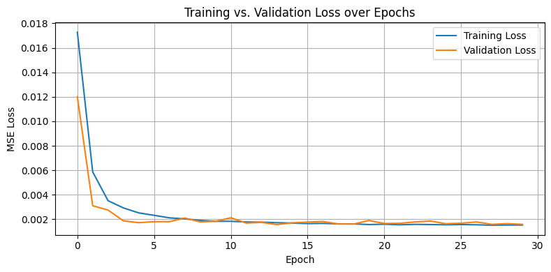

```python
import matplotlib.pyplot as plt

plt.figure(figsize=(8, 4))
plt.plot(metadata['train_losses'], label='Training Loss')
plt.plot(metadata['val_losses'], label='Validation Loss')
plt.title("Training vs. Validation Loss over Epochs")
plt.xlabel("Epoch")
plt.ylabel("MSE Loss")
plt.legend()
plt.grid(True)
plt.tight_layout()
plt.show()
```

- Plot the distribution of the reconstruction errors (i.e., differences between input and output data points).

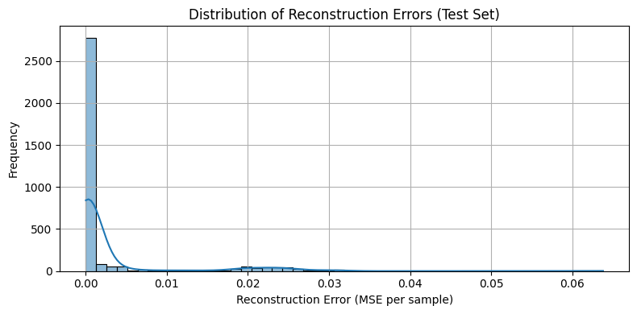

```python
import numpy as np
import seaborn as sns

# Compute reconstruction errors per test sample
best_model.eval()
X_test_tensor = torch.tensor(X_test, dtype=torch.float32).to(device)

with torch.no_grad():
    X_test_recon = best_model(X_test_tensor)

# Compute MSE for each sample (row-wise)
recon_errors = torch.mean((X_test_tensor - X_test_recon) ** 2, dim=1).cpu().numpy()

# Plot distribution
plt.figure(figsize=(8, 4))
sns.histplot(recon_errors, bins=50, kde=True)
plt.title("Distribution of Reconstruction Errors (Test Set)")
plt.xlabel("Reconstruction Error (MSE per sample)")
plt.ylabel("Frequency")
plt.grid(True)
plt.tight_layout()
plt.show()
```

Choose Anomaly Threshold (95th percentile)

```python
import numpy as np

threshold = np.percentile(recon_errors, 95)  # 95th percentile
print(f"Suggested anomaly threshold: {threshold:.6f}")
```

```
Suggested anomaly threshold: 0.023613
```

Flag Anomalies

```python
anomaly_flags = recon_errors > threshold
num_anomalies = np.sum(anomaly_flags)
print(f"Number of test anomalies detected: {num_anomalies} / {len(recon_errors)}")
```

```
Number of test anomalies detected: 170 / 3397
```

After evaluating the model on the test set, computed the reconstruction error (MSE) for each test sample. The distribution of these errors reveals how well the model generalizes to unseen data.

The histogram is plotted with a kernel density estimate (KDE) to visualize the error spread. Most reconstruction errors are concentrated near zero, indicating accurate reconstruction. However, a long right tail suggests a few samples are poorly reconstructed, potential anomalies.

To flag anomalies, selected a threshold based on the **95th percentile** of the error distribution. This means that the top 5% of samples with the highest reconstruction errors are considered anomalies.

- **Threshold used**: 95th percentile = *0.023613*
- **Anomalies detected**: *170* out of *3397*
4. Discuss and analyze:
- Describe your final RNN/LSTM architecture in detail (number of layers, types of layers, hidden size, dropout rate, etc.).

**Final Model Architecture: Dense vs. LSTM Comparison**

[output not shown]

**Performance Metrics**

| Metric | Value |
| --- | --- |
| Training MSE Loss | 0.0015 |
| Validation MSE Loss | 0.0016 |
| Testing MSE Loss | 0.0033 |
| Test MAE | 0.0314 |
| Test RMSE | 0.0579 |
| R² Score | 0.9166 |
| Anomaly Threshold (95%) | 0.0236 |
| Anomalies Detected | 170 / 3397 |

The final Dense Autoencoder achieved low reconstruction losses on all data splits, with a training loss of **0.0015**, validation loss of **0.0016**, and test loss of **0.0033**. These values indicate stable learning and strong generalization. The model also performed well on regression-based evaluation metrics, achieving a **Mean Absolute Error (MAE)** of **0.0314**, a **Root Mean Squared Error (RMSE)** of **0.0579**, and a high **R² score** of **0.9166**, suggesting that over 91% of the variance in the test data is captured by the model.

**Training Dynamics**

The training and validation loss curves demonstrate a smooth and consistent convergence without signs of overfitting. The validation curve closely follows the training curve, suggesting generalization is well-managed.

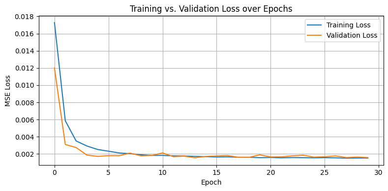

**Hyperparameter tuning** had a clear impact on the performance and stability of the Dense Autoencoder. As shown in the training vs. validation loss curve above, the model achieved a smooth and steadily declining loss trend, indicating effective learning and generalization.

**Reconstruction Error Distribution**

The reconstruction error histogram shows that most test samples are reconstructed with very low error, concentrated near 0. This indicates that the autoencoder successfully learned to represent the dominant patterns in the data. However, the right-skewed tail in the distribution reveals that a minority of samples exhibit higher reconstruction errors.

These cases may correspond to rare or anomalous patterns that the model failed to reconstruct accurately. To identify such anomalies, applied a threshold based on the 95th percentile of reconstruction errors, resulting in a cutoff of approximately 0.0236. Using this threshold, the model flagged 170 out of 3397 test samples as potential anomalies.

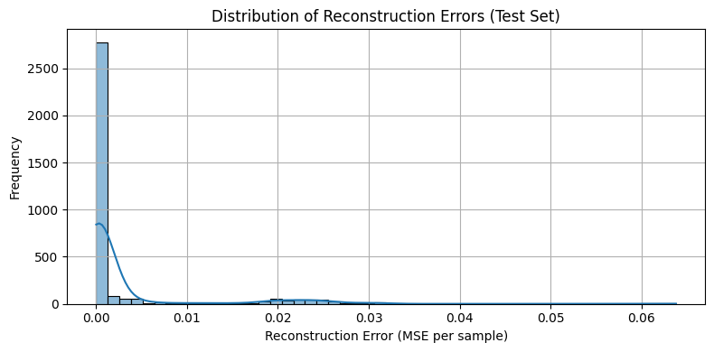

**Strengths:**

- **Unsupervised Learning**: Autoencoders do not require labeled anomalies, making them ideal when only normal data is available during training.
- **Reconstruction-Based Detection**: By learning to reconstruct normal patterns, autoencoders can naturally flag deviations as anomalies when reconstruction error is high.
- **Flexible Architectures**: Autoencoders can be adapted to different data types (e.g., Dense for tabular, LSTM for sequences, Conv1D for signals).
- **Scalable and Efficient**: Once trained, inference is fast and scalable to large datasets.
- **Anomaly Localization**: In some applications (e.g., images or sequences), reconstruction error can be analyzed per feature or timestep to localize anomalous regions.

**Limitations:**

- **Dependence on Training Data Quality**: If anomalous patterns appear in training data, the model may learn to reconstruct them, reducing anomaly sensitivity.
- **Threshold Selection**: Choosing a suitable reconstruction error threshold is non-trivial and may require domain knowledge or heuristic methods (e.g., percentiles).
- **Limited Interpretability**: Autoencoders provide limited insights into why a data point is considered anomalous.
- **Overfitting Risk**: With excessive model capacity, autoencoders may overfit and reconstruct even anomalous samples well, leading to false negatives.
- **Sensitivity to Hyperparameters**: Performance can vary significantly based on architecture depth, bottleneck size, and regularization, requiring careful tuning.
5. References. Include details on all the resources used to complete this part, e.g. links to datasets, research papers or articles, code examples or tutorials you referred.

### References

- **PyTorch Documentation**  
  Official documentation for PyTorch APIs used in model building, training, and evaluation.  
  https://pytorch.org/docs/stable/index.html
- **Anomaly Detection with Autoencoders in PyTorch**  
  Tutorials and guides on building autoencoders for anomaly detection.  
  https://www.geeksforgeeks.org/implementing-an-autoencoder-in-pytorch/
- **Sklearn Metrics Documentation**  
  Used for computing MAE, RMSE, and R² metrics on the test data.  
  https://scikit-learn.org/stable/modules/classes.html#module-sklearn.metrics
- **KDE and Histogram Plotting with Seaborn**  
  Used for visualizing reconstruction error distribution.  
  https://seaborn.pydata.org/generated/seaborn.kdeplot.html
- **Model Architectures and Concepts**
  - **Autoencoder Theory (Dense & General)**
  - Baldi, P. (2012). *Autoencoders, Unsupervised Learning, and Deep Architectures*. Proceedings of ICML Workshop on Unsupervised and Transfer Learning.  
    http://proceedings.mlr.press/v27/baldi12a/baldi12a.pdf
  - Goodfellow, I., Bengio, Y., & Courville, A. (2016). *Deep Learning* (Chapter 14). MIT Press.  
    https://www.deeplearningbook.org/
- **LSTM Autoencoder for Anomaly Detection**
  - Malhotra et al., *LSTM-based Encoder-Decoder for Multi-sensor Anomaly Detection*  
    https://arxiv.org/abs/1607.00148
- **Conv1D Autoencoder**
  - Zheng et al. (2019), *Time Series Classification Using Multi-Channels Deep Convolutional Neural Networks*  
    https://scispace.com/pdf/time-series-classification-using-multi-channels-deep-1jehc4yp2b.pdf
  - Inspiration adapted from:  
    https://towardsdatascience.com/autoencoders-an-ultimate-guide-for-data-scientists-dca3e56a070e/
- **Dataset Source**
  - *Machine Temperature System Failure Dataset*  
    Kaggle Dataset: https://www.kaggle.com/boltzmannbrain/nab.